# Disaster Relief Project

Mohamad El Iskandarani

May 09, 2022

**SYS 6018 | Spring 2022 | University of Virginia**

# Introduction

Disaster struck Haiti in 2010, whereby a destructive earthquake left many people homeless and in need of food, water, and shelter. Rescue workers from the US military are in charge of delivering supplies to the people in need. This project aims to process the high-resolution imagery taken by the RIT aircraft to locate the blue tarps that indicate the presence of survivors. The project utilizes several data-mining approaches, whereby it sets up the models, trains them, and compares them to arrive at the best model suited for this task.

# Training Data EDA

```r
# Load Required Packages
library(tidyverse)
library(ggplot2)
library(dplyr)
library(mlbench)
library(glmnet)
library(yardstick)
library(R6018)
library(ISLR)
library(caret)
library(FNN)
library(broom)
library(fastDummies)
library(e1071)
library(rpart)
#Load data
haiti_training = read.csv("~/SYS 6018/projectparti/HaitiTraining.csv")

#Data exploration
summary(haiti_training)
```

```
#>     Class                Red          Green            Blue
#>  Length:63241       Min.   : 48   Min.   : 48.0   Min.   : 44.0
#>  Class :character   1st Qu.: 80   1st Qu.: 78.0   1st Qu.: 63.0
#>  Mode  :character   Median :163   Median :148.0   Median :123.0
#>                     Mean   :163   Mean   :153.7   Mean   :125.1
#>                     3rd Qu.:255   3rd Qu.:226.0   3rd Qu.:181.0
#>                     Max.   :255   Max.   :255.0   Max.   :255.0
```

```r
haiti_training %>%
   group_by(Class) %>%
   summarise(n = n()) %>%
   ungroup() %>%
   mutate(p = (n/nrow(haiti_training)))
```

```
#> # A tibble: 5 x 3
#>   Class                n      p
#>   <chr>            <int>  <dbl>
#> 1 Blue Tarp         2022 0.0320
#> 2 Rooftop           9903 0.157
#> 3 Soil             20566 0.325
#> 4 Various Non-Tarp  4744 0.0750
#> 5 Vegetation       26006 0.411
```

The dataset has 63,241 observations, each having Red, Green, and Blue values as predictors. There are five possible classes: blue tarp, rooftop, soil, various non tarp, and vegetation. As seen from the probability table, blue tarps consist only 3.19% of the observations, whereby vegetation and soil consist the majority.

# Model Training

## Set-up

No scaling will be done, since the RGB values have the same range. Since the goal is to classify as blue tarp or not (i.e. we don’t care if it’s soil or vegetation or etc.), I will create a new binary column named BlueTarp which will act as the output variable of interest.

```r
haiti_training = dummy_cols(haiti_training, select_columns = c("Class"))
haiti_training = filter(haiti_training) %>% select(c("Class_Blue Tarp","Red","Green","Blue"))
haiti_training = rename(haiti_training,"Blue_Tarp" = "Class_Blue Tarp")
haiti_training_nolabel = select(haiti_training, -Blue_Tarp)
# Setting up the data
X.train = filter(haiti_training) %>% select(-c("Blue_Tarp")) %>%as.matrix()
Y.train = haiti_training$Blue_Tarp


n = nrow(haiti_training) # number of training observations
n.folds = 10 # number of folds for cross-validation
set.seed(2021) # set seed for reproducibility
```

## Logistic Regression

For logistic regression, I implemented 10-fold CV using a loop. I collected the results of the loop at the end. The performance metrics of interest are stored in a tibble to later on plot the ROC curve and derive the threshold. There are no parameters to tune here.

```r
set.seed(2021)
fold = sample(rep(1:n.folds, length=n)) # I will use the same sampling for all models.

G.truth = vector()
LR_RESULTS = tibble()

for(j in 1:n.folds){
  #-- Set training/val data
  val = which(fold == j) # indices of holdout/validation data
  train = which(fold != j) # indices of fitting/training data
  n.val = length(val) # number of observations in validation
  G.test = haiti_training$Blue_Tarp[val]
  data_fit = slice(haiti_training, train)
  data_eval = slice(haiti_training, val)
  #- fit and evaluate models
  fit.lr = glm(Blue_Tarp ~ Red + Green + Blue, data = data_fit,
             family="binomial")
  prob.lr = predict(fit.lr, newdata = data_eval, type="response") # probabilities
  link.lr = predict(fit.lr, newdata = data_eval, type="link")     # logit (linear part)
  results_temp = tibble(prob.lr,link.lr)
  #- update RESULTS
  LR_RESULTS = bind_rows(LR_RESULTS, results_temp)
  G.truth = append(G.truth,G.test)
}

LR_PERF = tibble(truth = G.truth, gamma = LR_RESULTS$link.lr, p.hat = LR_RESULTS$prob.lr) %>%
  #- group_by() + summarize() in case of ties
  group_by(gamma, p.hat) %>%
  summarize(n=n(), n.1=sum(truth), n.0=n-sum(truth)) %>% ungroup() %>%
  #- calculate metrics
  arrange(gamma) %>%
  mutate(FN = cumsum(n.1),    # false negatives
         TN = cumsum(n.0),    # true negatives
         TP = sum(n.1) - FN,  # true positives
         FP = sum(n.0) - TN,  # false positives
         N = cumsum(n),       # number of cases predicted to be 1
         TPR = TP/sum(n.1), FPR = FP/sum(n.0)) %>%
  #- only keep relevant metrics
  select(-n, -n.1, -n.0, gamma, p.hat)

LR_RESULTS = tibble(truth = G.truth, gamma = LR_RESULTS$link.lr, p.hat = LR_RESULTS$prob.lr)
```

## KNN

For the KNN model, I only have one parameter to tune, which is $k$. Given the relatively big observation set, I suspect that we won’t run into the same problem that occurred in HW2, where a non-optimal $k$ was picked by cross validation due to the data set’s relatively small size of 100 observations. I searched over the range of $k$ [3,50]. The choice of range was arbitrary. In my implementation, I used the $knn3()$ function, predicted the probabilities of the evaluation set using $predict()$, and captured the probabilities of detecting class 1. It could be done using $knn()$ or $knn.reg()$ functions, but I like this approach because it shows what I’m doing step by step. In order to pick the optimal $k$, I will use the AUROC since it is one of the metrics in the performance table.

```r
#- Initialize
set.seed(2021)
K = 3:50                                # set of k values for kNN
n.val = numeric(n.folds)                # number of elements in validation sets
columns = c("Red","Green","Blue","Blue_Tarp")
levs = c("1", "0")

KNN_RESULTS = tibble()
AUROC_KNN = tibble()

#-- fit set of knn models
for(i in 1:length(K)){
  k = K[i]

  #- Iterate over folds
    for(j in 1:n.folds){

    #-- Set training/val data
    val = which(fold == j)
    train = which(fold != j)
    n.val[j] = length(val)

    knn = knn3(Blue_Tarp ~ ., data = haiti_training[train,columns, drop=FALSE], k = k)
    prob.knn = predict(knn, newdata = haiti_training[val,columns, drop=FALSE], type="prob") # probabilities
    prob.knn = prob.knn[,2] #Probabilities of class 1, which is detecting Blue Tarp
    G.test = haiti_training$Blue_Tarp[val] #The truth values used for evaluation

    results = tibble(truth = G.test, prob.knn)
    KNN_RESULTS = bind_rows(KNN_RESULTS,results)

    }
  # For each k, I will calculate the AUROC.
  auroc = KNN_RESULTS %>%
  yardstick::roc_auc(truth = factor(truth, levels=levs), estimate = prob.knn)
  auroc_temp = tibble(k = k,auroc = auroc$.estimate)
  AUROC_KNN = bind_rows(AUROC_KNN,auroc_temp)
  KNN_RESULTS = tibble() #Empty the tibble
}

AUROC_KNN$k[AUROC_KNN$auroc==max(AUROC_KNN$auroc)]
```

```
#> [1] 39
```

Based on the results above,$k_{optimal} = 39$. Next, we perform cross validation using $k_{optimal}$ and store our performance metrics of interest in a tibble to later on plot the ROC curve and derive the threshold.

```r
set.seed(2021)
k_optimal = 39
KNN_PERF = tibble()
KNN_RESULTS = tibble()

  #- Iterate over folds
    for(j in 1:n.folds){

    #-- Set training/val data
    val = which(fold == j)
    train = which(fold != j)
    n.val[j] = length(val)

    knn = knn3(Blue_Tarp ~ ., data = haiti_training[train,columns, drop=FALSE], k = k_optimal)
    prob.knn = predict(knn, newdata = haiti_training[val,columns, drop=FALSE], type="prob") # probabilities
    prob.knn = prob.knn[,2] #Probabilities of class 1, which is detecting Blue Tarp
    G.test = haiti_training$Blue_Tarp[val] #The truth values used for evaluation

    results = tibble(truth = G.test, p.hat = prob.knn)
    KNN_RESULTS = bind_rows(KNN_RESULTS,results)
    }

gamma = log((KNN_RESULTS$p.hat)/(1-KNN_RESULTS$p.hat))
KNN_PERF = tibble(KNN_RESULTS,gamma) %>%
  group_by(gamma,p.hat) %>%
  summarize(n=n(), n.1=sum(truth), n.0=n-sum(truth)) %>% ungroup() %>%
  #- calculate metrics
  arrange(gamma) %>%
  mutate(FN = cumsum(n.1),    # false negatives
         TN = cumsum(n.0),    # true negatives
         TP = sum(n.1) - FN,  # true positives
         FP = sum(n.0) - TN,  # false positives
         N = cumsum(n),       # number of cases predicted to be 1
         TPR = TP/sum(n.1), FPR = FP/sum(n.0)) %>%
  #- only keep relevant metrics
  select(-n, -n.1, -n.0,gamma,p.hat)

KNN_RESULTS = tibble(KNN_RESULTS, gamma)
```

## Penalized Logistic Regression (ElasticNet)

When it comes to penalized logistic regression, I have to tune parameters $\lambda$ and $\alpha$.I will fit and find $\lambda_{min}$ that minimizes the cross validation error which is why I won’t consider $\lambda_{1SE}$, but I will compare for the sake of proof. To do that, I put the $type.measure = deviance$ to use the log-loss function as my loss function.

```r
set.seed(2021)
#To find optimal lambda

alpha = 1

pred_data = tibble()

#Use 10-fold CV to estimate lambda

fit = cv.glmnet(x = X.train, y=Y.train,alpha=alpha, family="binomial",type.measure="deviance",foldid=fold)
min(fit$cvm)
```

```
#> [1] 0.02812682
```

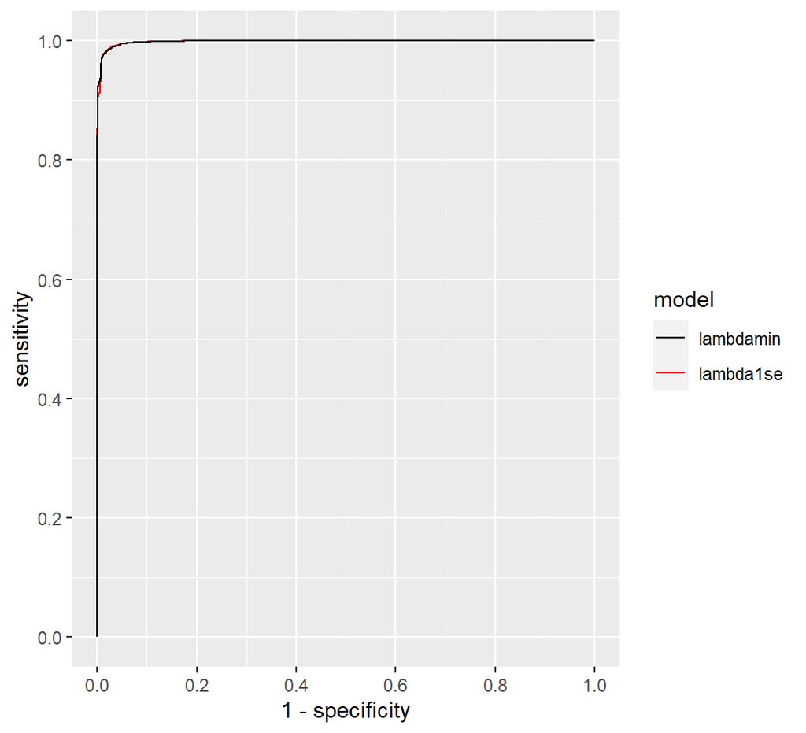

```r
lambda_min = fit$lambda.min

pred_temp =
  tibble(
    lambdamin = predict(fit, s="lambda.min", newx=X.train, type="link")[,1],
    lambda1se = predict(fit, s="lambda.1se", newx=X.train, type="link")[,1],
    linked = Y.train%>% factor(levels=c(1,0)))
pred_data = bind_rows(pred_data,pred_temp)

pred_data= pred_data %>%
  gather(model, prediction, lambdamin, lambda1se) %>%
  group_by(model) %>%
  roc_curve(truth = linked, prediction)

#Plot ROC Curve
pred_data %>%
  ggplot(aes(1-specificity, sensitivity, color=model)) +
  geom_path() +
  scale_color_manual(values=c(lambdamin='black', lambda1se='red')) +
  scale_x_continuous(breaks=seq(0, 1, by=.2)) +
  scale_y_continuous(breaks=seq(0, 1, by=.2))
```

$\lambda_{min} = 5.5*10^{-6}$. As we can see from the ROC curves, $\lambda_{min}$ is slightly better for a certain set of thresholds, which is why I will use it instead of $\lambda_{1SE}$.

For the $\alpha$ parameter, I will perform a grid search from 0 to 1 to find the $\alpha$ that minimizes the CVM given $\lambda_{min}$. I could have used AUROC as the performance metric similar to what I’ve done in KNN, but I decided not to because it was too time consuming. The step choice of 0.1 is arbitrary.I could have chosen a smaller step size such as 0.01, but I didn’t want the loop to take too much computing time.

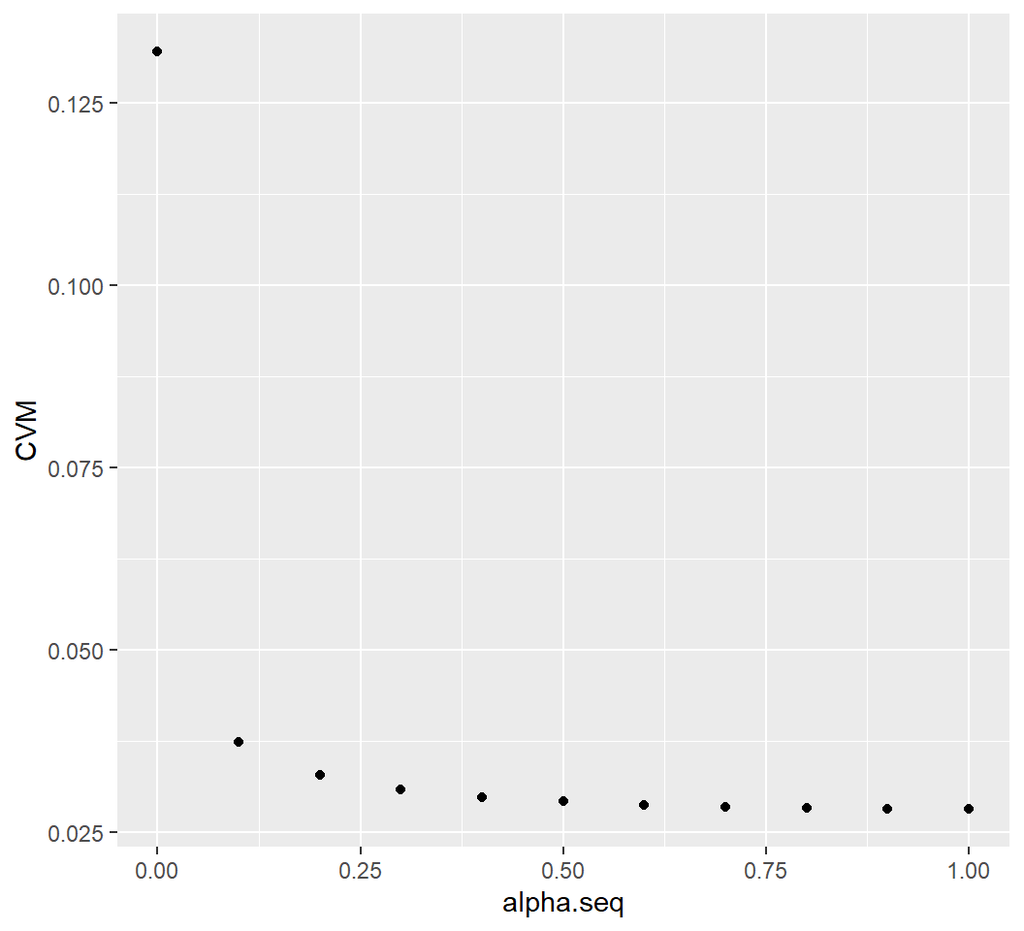

```r
#To find optimal alpha

set.seed(2021)
K = 10           # number of folds

#-- Function that returns the minimum cross validation error according to the log loss function for a given alpha
est_cvm <- function(alpha, folds){
  min(cv.glmnet(X.train, Y.train, foldid = fold, alpha=alpha, family="binomial",type.measure="deviance")$cvm)
}

#-- Set alpha sequence
alpha.seq = seq(0, 1, by=.1)

#-- estimate scores
CVM = sapply(alpha.seq, est_cvm, folds=fold)

#-- Plot results
qplot(alpha.seq, CVM)
```

```r
min(CVM)
```

```
#> [1] 0.02812682
```

Based on the plot, $\alpha_{optimal} = 1$, which makes it a lasso model.Thus, the final penalized logistic regression model will be the one below, having $\lambda_{min} =5.5*10^{-6}$, and $\alpha_{optimal} = 1$. The metrics of interest are stored in a tibble to later on plot the ROC curve and derive the threshold.

```r
set.seed(2021)
alpha_optimal = 1

fit.enet = cv.glmnet(x = X.train, y=Y.train,alpha=alpha_optimal, family="binomial",foldid=fold)

#Predictions
gamma.enet = predict(fit.enet, s="lambda.min", newx=X.train, type="link")[,1]
prob.enet = predict(fit.enet, s="lambda.min", newx=X.train, type="response")[,1]

ENET_RESULTS = tibble(truth = Y.train ,gamma = gamma.enet , p.hat = prob.enet )
#Metrics
ENET_PERF = tibble(truth = Y.train, gamma = gamma.enet , p.hat = prob.enet) %>%
  group_by(gamma,p.hat) %>%
  summarize(n=n(), n.1=sum(truth), n.0=n-sum(truth)) %>% ungroup() %>%
  #- calculate metrics
  arrange(gamma) %>%
  mutate(FN = cumsum(n.1),    # false negatives
         TN = cumsum(n.0),    # true negatives
         TP = sum(n.1) - FN,  # true positives
         FP = sum(n.0) - TN,  # false positives
         N = cumsum(n),       # number of cases predicted to be 1
         TPR = TP/sum(n.1), FPR = FP/sum(n.0)) %>%
  #- only keep relevant metrics
  select(-n, -n.1, -n.0,gamma,p.hat)
```

## Support Vector Machines (SVM)

```r
tune_grid = expand_grid(
  cost = 10^(-2:2),
  gamma = c(.1, .5, 1))

eval_svm <- function(data_train, data_test, cost, gamma){

  #fit
  fit = svm(factor(Blue_Tarp) ~ Red + Green + Blue,
            data = data_train,
            #: tuning parameters
            kernel = "radial",
            gamma = gamma,
            cost = cost
            )

  #predict
  pred = predict(fit, data_test, decision.values = TRUE)

  #: evaluate
  eval_data = tibble(
    outcome = data_test$Blue_Tarp,
    pred_hard = c(pred),
    pred_soft = as.numeric(attr(pred, "decision.values"))
  )

  auroc = eval_data %>%
    yardstick::roc_auc(truth = factor(outcome, levels=levs), estimate = pred_soft)

  accuracy = eval_data %>%
      yardstick::accuracy(truth = factor(outcome, levels=levs),
                          estimate = factor(pred_hard, levels=levs))

  bind_rows(auroc, accuracy) %>%
    mutate(cost, gamma)  # add tuning parameters
}

out = tibble()

for(j in n.folds){

  for(i in 1:nrow(tune_grid)){
    val = which(fold == j) # indices of holdout/validation data
    train = which(fold != j) # indices of fitting/training data

    metrics = eval_svm(
      data_train = slice(haiti_training,train),
      data_test = slice(haiti_training,val),
      cost = tune_grid$cost[i],
      gamma = tune_grid$gamma[i]
    )

    out = bind_rows(out, metrics %>% mutate(fold = j) )
  }
}

#: average over folds

out %>%
  # calculate average performance over folds
  group_by(.metric, cost, gamma) %>%
  summarize(mu = mean(.estimate), .groups = "drop") %>%
  # spread data wider to see both metrics
  pivot_wider(names_from = .metric, values_from = mu) %>%
  # arrange by auc and then accuracy (if ties)
  arrange(desc(roc_auc), desc(accuracy))
```

```
#> # A tibble: 15 x 4
#>      cost gamma accuracy  roc_auc
#>     <dbl> <dbl>    <dbl>    <dbl>
#>  1   0.01   0.1    0.979 0.00175
#>  2   0.01   1      0.989 0.000766
#>  3   0.1    0.1    0.992 0.000701
#>  4   0.01   0.5    0.987 0.000670
#>  5   0.1    0.5    0.993 0.000623
#>  6   0.1    1      0.994 0.000611
#>  7   1      0.1    0.994 0.000601
#>  8   1      0.5    0.995 0.000538
#>  9  10      0.1    0.995 0.000528
#> 10   1      1      0.995 0.000499
#> 11 100      0.1    0.995 0.000491
#> 12  10      0.5    0.995 0.000460
#> 13  10      1      0.996 0.000398
#> 14 100      0.5    0.996 0.000380
#> 15 100      1      0.996 0.000344
```

Based on the results above, we will go with $cost = 0.1$ and $\gamma = 0.1$. The reason I didn’t go with the topmost row is because I don’t want to solely prioritize AUROC as my criterion, so I went with parameters that provided good AUROC and accuracy. $eval_svm1()$ is similar to the $eval_svm()$ function above but outputs probabilities which I will use to create the performance metrics tibble SVM_PERF.

```r
cost_optimal = 0.1
gamma_optimal = 0.1

eval_svm1 <- function(data_train, data_test, cost, gamma){

  #fit
  fit = svm(factor(Blue_Tarp) ~ Red + Green + Blue,
            data = data_train,
            #: tuning parameters
            kernel = "radial",
            gamma = gamma,
            cost = cost,
            probability = TRUE)

    #predict
  pred = predict(fit, slice(haiti_training,val), probability = TRUE)
  preds = attributes(pred)$probabilities[,2]
  gamma = log(preds)/(1-preds)

  eval_data = tibble(
    truth = data_test$Blue_Tarp,
    gamma = gamma,
    p.hat = c(pred)
  )

}


SVM_RESULTS = tibble()

for(j in n.folds){

    val = which(fold == j) # indices of holdout/validation data
    train = which(fold != j) # indices of fitting/training data

  #fit
  fit.svm = svm(factor(Blue_Tarp) ~ Red + Green + Blue,
            data = slice(haiti_training,train),
            #: tuning parameters
            kernel = "radial",
            gamma = gamma_optimal,
            cost = cost_optimal,
            probability = TRUE)

    out_temp = eval_svm1(
      data_train = slice(haiti_training,train),
      data_test = slice(haiti_training,val),
      cost = cost_optimal,
      gamma = gamma_optimal
    )

    SVM_RESULTS = bind_rows(SVM_RESULTS, out_temp)
}

#Metrics
SVM_PERF = SVM_RESULTS %>%
  group_by(gamma,p.hat) %>%
  summarize(n=n(), n.1=sum(truth), n.0=n-sum(truth)) %>% ungroup() %>%
  #- calculate metrics
  arrange(gamma) %>%
  mutate(FN = cumsum(n.1),    # false negatives
         TN = cumsum(n.0),    # true negatives
         TP = sum(n.1) - FN,  # true positives
         FP = sum(n.0) - TN,  # false positives
         N = cumsum(n),       # number of cases predicted to be 1
         TPR = TP/sum(n.1), FPR = FP/sum(n.0)) %>%
  #- only keep relevant metrics
  select(-n, -n.1, -n.0,gamma,p.hat)
```

## Naive Bayes

```r
set.seed(2021)

BAYES_RESULTS = tibble()
for(j in n.folds){

  val = which(fold == j) # indices of holdout/validation data
  train = which(fold != j) # indices of fitting/training data

  #fit
  bayes = e1071::naiveBayes(factor(Blue_Tarp) ~ Red + Green + Blue,
            data = slice(haiti_training,train))
  #predict
  val_temp = slice(haiti_training,val)
  truth_temp = slice(haiti_training,val)$Blue_Tarp
  pred_temp = predict(bayes, val_temp, type="raw")
  preds = pred_temp[,2]
  gamma_temp = log(preds)/(preds)

  results_temp = tibble(p.hat = preds[1:6324],truth =truth_temp,gamma = gamma_temp[1:6324])
  BAYES_RESULTS = bind_rows(BAYES_RESULTS,results_temp)
}

#Metrics
BAYES_PERF = BAYES_RESULTS %>%
  group_by(gamma,p.hat) %>%
  summarize(n=n(), n.1=sum(truth), n.0=n-sum(truth)) %>% ungroup() %>%
  #- calculate metrics
  arrange(gamma) %>%
  mutate(FN = cumsum(n.1),    # false negatives
         TN = cumsum(n.0),    # true negatives
         TP = sum(n.1) - FN,  # true positives
         FP = sum(n.0) - TN,  # false positives
         N = cumsum(n),       # number of cases predicted to be 1
         TPR = TP/sum(n.1), FPR = FP/sum(n.0)) %>%
  #- only keep relevant metrics
  select(-n, -n.1, -n.0,gamma,p.hat)
```

## LDA

```r
set.seed(2021)

LDA_RESULTS = tibble()
for(j in n.folds){

  val = which(fold == j) # indices of holdout/validation data
  train = which(fold != j) # indices of fitting/training data

  #fit
  ld = MASS::lda(factor(Blue_Tarp) ~ Red + Green + Blue,
            data = slice(haiti_training,train))
  #predict
  val_temp = slice(haiti_training,val)
  truth_temp = slice(haiti_training,val)$Blue_Tarp
  pred_temp = predict(ld, val_temp, probability = TRUE)
  pred_temp = pred_temp$posterior[,2]
  gamma_temp = log(pred_temp)/(1-pred_temp)

  results_temp = tibble(p.hat = pred_temp[1:6324],truth =truth_temp,gamma = gamma_temp[1:6324])
  LDA_RESULTS = bind_rows(LDA_RESULTS,results_temp)
}

#Metrics
LDA_PERF = LDA_RESULTS %>%
  group_by(gamma,p.hat) %>%
  summarize(n=n(), n.1=sum(truth), n.0=n-sum(truth)) %>% ungroup() %>%
  #- calculate metrics
  arrange(gamma) %>%
  mutate(FN = cumsum(n.1),    # false negatives
         TN = cumsum(n.0),    # true negatives
         TP = sum(n.1) - FN,  # true positives
         FP = sum(n.0) - TN,  # false positives
         N = cumsum(n),       # number of cases predicted to be 1
         TPR = TP/sum(n.1), FPR = FP/sum(n.0)) %>%
  #- only keep relevant metrics
  select(-n, -n.1, -n.0,gamma,p.hat)
```

## QDA

```r
set.seed(2021)

QDA_RESULTS = tibble()
for(j in n.folds){

  val = which(fold == j) # indices of holdout/validation data
  train = which(fold != j) # indices of fitting/training data

  #fit
  qd = MASS::qda(factor(Blue_Tarp) ~ Red + Green + Blue,
            data = slice(haiti_training,train))
  #predict
  val_temp = slice(haiti_training,val)
  truth_temp = slice(haiti_training,val)$Blue_Tarp
  pred_temp = predict(qd, val_temp, probability = TRUE)
  pred_temp = pred_temp$posterior[,2]
  gamma_temp = log(pred_temp)/(1-pred_temp)

  results_temp = tibble(p.hat = pred_temp[1:6324],truth =truth_temp,gamma = gamma_temp[1:6324])
  QDA_RESULTS = bind_rows(QDA_RESULTS,results_temp)
}

#Metrics
QDA_PERF = QDA_RESULTS %>%
  group_by(gamma,p.hat) %>%
  summarize(n=n(), n.1=sum(truth), n.0=n-sum(truth)) %>% ungroup() %>%
  #- calculate metrics
  arrange(gamma) %>%
  mutate(FN = cumsum(n.1),    # false negatives
         TN = cumsum(n.0),    # true negatives
         TP = sum(n.1) - FN,  # true positives
         FP = sum(n.0) - TN,  # false positives
         N = cumsum(n),       # number of cases predicted to be 1
         TPR = TP/sum(n.1), FPR = FP/sum(n.0)) %>%
  #- only keep relevant metrics
  select(-n, -n.1, -n.0,gamma,p.hat)
```

## Random Forest

As discussed in HW 6, the most influential parameter to tune is mtry. For the sake of computation time and as discussed in HW 6, ntree should only be set large enough, so I won’t tune it. Due to the limitations of my laptop, I couldn’t push ntree beyond 1,000 (failed to allocate vector of size 1.3 Gb) nor go for 10 folds, so I will go for 5 folds. I concatenated the predictions for all 5 folds and calculated 1 AUROC value per mtry. Based on AUROC, the optimal tuning parameters are $mtry = 2$, $ntree = 1000$.

```r
Y.train = haiti_training$Blue_Tarp
haiti_training1 = haiti_training
# Outcomes should be made as factors so that the RF becomes a classification forest.
haiti_training1$Class = as.factor(haiti_training$Blue_Tarp)

set.seed(2021)
K = 5           # number of folds
ntree = 1000
mtry_seq = seq(1, 3, by=1)  # grid of tuning parameters

RF_RESULTS = tibble()
RF_PERF = tibble()
for (mtry in mtry_seq){
    for(k in 1:K){
      set.seed(2021)
      test = (fold == k)
      train = (fold != k)
      rf = randomForest::randomForest(Class ~ ., data = haiti_training1[train, ],mtry = mtry, ntree = ntree)
      phat = predict(rf, haiti_training1[test, ],type="prob")
      rf_temp = tibble(mtry = mtry,ntree = ntree,fold = k,truth = haiti_training1[test,]$Class , phat = phat[,2])
      RF_RESULTS = bind_rows(RF_RESULTS,rf_temp)
    }
        # For each mtry, I will calculate the AUROC and pick the optimal tuning parameters based on it.
      auroc = RF_RESULTS %>%
      yardstick::roc_auc(truth = factor(truth, levels=levs), estimate = phat)
      auroc_temp = tibble(mtry = mtry,auroc = auroc$.estimate)
      RF_PERF = bind_rows(RF_PERF,auroc_temp)
      RF_RESULTS = tibble() #Empty the tibble
}
AUROC = RF_PERF[1,]$auroc
```

Now, we train the optimal model to find the performance metrics.

```r
K = 10
mtry_opt = 2
ntree_opt = 1000
P.truth = vector() #I'm saving this to use it in the performance metric calculations,because I found that the truth labels as factors were problematic in calculating the metrics.
RF_p.hat = vector()
for(k in 1:K){
    set.seed(2021)
    test = (fold == k)
    train = (fold != k)
    rf_opt = randomForest::randomForest(Class ~ ., data = haiti_training1[train, ],mtry = mtry_opt, ntree = ntree_opt)
    phat = predict(rf_opt, haiti_training1[test, ],type="prob")
    rf_temp = phat[,2]
    RF_p.hat = append(RF_p.hat,rf_temp)
    truth = truth = haiti_training[test,]$Blue_Tarp
    P.truth = append(P.truth,truth)
}

gamma = log((RF_p.hat)/(1-RF_p.hat))

RF_RESULTS = tibble(truth = P.truth, p.hat = RF_p.hat, gamma)
RF_PERF = RF_RESULTS %>% group_by(gamma,p.hat) %>%
  summarize(n=n(), n.1=sum(truth), n.0=n-sum(truth)) %>% ungroup() %>%
  #- calculate metrics
  arrange(gamma) %>%
  mutate(FN = cumsum(n.1),    # false negatives
         TN = cumsum(n.0),    # true negatives
         TP = sum(n.1) - FN,  # true positives
         FP = sum(n.0) - TN,  # false positives
         N = cumsum(n),       # number of cases predicted to be 1
         TPR = TP/sum(n.1), FPR = FP/sum(n.0)) %>%
  #- only keep relevant metrics
  select(-n, -n.1, -n.0,gamma,p.hat)
```

## Boosted Trees

I will be using the XGBoost algorithm. The tuning parameters are learning rate and number of rounds. I will perform a grid search to find the optimal learning rate and number of rounds. The metric for the XGBoost will be AUROC. Max depth has been arbitrarily set to 3. Based on our grid search, the optimal parameters are $eta = 0.07$ , $nrounds = 700$.

```r
set.seed(2021)
tune_grid = expand_grid(
  nb_rounds = seq(100, 1000, by=200),
  eta = seq(0.01, 0.1, by=0.02))

out = tibble()
BOOST_AUROC = tibble()

for(i in 1:nrow(tune_grid)){

    xgb = xgboost::xgb.cv(
      data = as.matrix(X.train),
      label = Y.train,
      eta = tune_grid$eta[i],
      nrounds = tune_grid$nb_rounds[i],
      max_depth = 3,
      objective = "binary:logistic",
      nfold = 10,
      prediction = TRUE,
      metrics = "auc",
      verbose = FALSE
      )

      xgb_pred = xgb$pred
      out = tibble(Y.train,xgb_pred)
      auroc = out %>%
      yardstick::roc_auc(truth = factor(Y.train, levels=levs), estimate = xgb_pred)
      auroc_temp = tibble(eta = tune_grid$eta[i],nrounds = tune_grid$nb_rounds[i],auroc = auroc$.estimate)
      BOOST_AUROC  = bind_rows(BOOST_AUROC,auroc_temp)
      out = tibble()
}
```

Now, we perform cross validation to report the performance metrics.

```r
eta_opt = 0.07
nrounds_opt = 700

set.seed(2021)
xgb_opt = xgboost::xgb.cv(
    data = as.matrix(X.train),
    label = Y.train,
    eta = eta_opt,
    nrounds = nrounds_opt,
    max_depth = 3,
    objective = "binary:logistic",
    nfold = 10,
    prediction = TRUE,
    metrics = "auc",
    verbose = FALSE
    )

xgb_pred_opt = xgb_opt$pred
BOOST_gamma = log((xgb_pred_opt)/(1-xgb_pred_opt))
BOOST_RESULTS = tibble(truth = Y.train, p.hat = xgb_pred_opt, gamma = BOOST_gamma)
BOOST_PERF = BOOST_RESULTS%>%
  group_by(gamma,p.hat) %>%
  summarize(n=n(), n.1=sum(truth), n.0=n-sum(truth)) %>% ungroup() %>%
  #- calculate metrics
  arrange(gamma) %>%
  mutate(FN = cumsum(n.1),    # false negatives
         TN = cumsum(n.0),    # true negatives
         TP = sum(n.1) - FN,  # true positives
         FP = sum(n.0) - TN,  # false positives
         N = cumsum(n),       # number of cases predicted to be 1
         TPR = TP/sum(n.1), FPR = FP/sum(n.0)) %>%
  #- only keep relevant metrics
  select(-n, -n.1, -n.0,gamma,p.hat)
```

## Threshold Selection

As can be seen from the parts above, I created ranges of thresholds for each model. Each row in each of the tibbles LR_PERF, KNN_PERF, ENET_PERF, and SVM_PERF represents the performance metrics according to a given threshold. Naturally, we want a threshold that maximizes the TPR while minimizing the FPR. For example, a threshold that yields 1 TPR but 1 FPR isn’t really useful, for it means that the model is labeling everything as true (or 1). A threshold that, for example, yields 0.999 TPR and 0.15 FPR is a better threshold.

We can choose arbitrary values for $C_{FP}$ and $C_{FN}$, and calculate a theoretical optimal threshold. In this case, I will set $C_{FP} = 1$ and $C_{FN} = 6$, since I see that the cost of a false negative (not helping someone in need) is more precious than falsely identifying a blue tarp. Based on my arbitrary values, the threshold becomes $\frac{1}{1+6} = \frac{1}{7} = 0.1428$. Thus, my threshold is $p =~0.1428$.

# Results (Cross-Validation)

## Performance Table

For CV, I essentially used all the predictions from all folds to calculate my metrics. In other words, I concatenated all the resulting predictions from the folds.

```r
# I found the rows manually and binded them to a single tibble. I found the closest p value to the threshold.
Model = c("Logistic Regression","KNN","ElasticNet","SVM","Naive Bayes","LDA","QDA","Random Forest","Boosted Trees")
Tuning = c("","k = 39","lambda_min = 5.5e-6 & alpha  = 1","cost = 0.1 & gamma  = 0.1","","","","mtry = 2, ntree = 1000","eta = 0.07 & nrounds = 700")
PERF_THRES1 = tibble()
PERF_THRES1 = bind_rows(PERF_THRES1,LR_PERF[47464,c("TPR","FPR")])
PERF_THRES1 = bind_rows(PERF_THRES1,KNN_PERF[48,c("TPR","FPR")])
PERF_THRES1 = bind_rows(PERF_THRES1,ENET_PERF[26483,c("TPR","FPR")])
PERF_THRES1 = bind_rows(PERF_THRES1,SVM_PERF[3189,c("TPR","FPR")])
PERF_THRES1 = bind_rows(PERF_THRES1,BAYES_PERF[4699,c("TPR","FPR")])
PERF_THRES1 = bind_rows(PERF_THRES1,LDA_PERF[4764,c("TPR","FPR")])
PERF_THRES1 = bind_rows(PERF_THRES1,QDA_PERF[4763,c("TPR","FPR")])
PERF_THRES1 = bind_rows(PERF_THRES1,RF_PERF[18,c("TPR","FPR")])
PERF_THRES1 = bind_rows(PERF_THRES1,BOOST_PERF[13128,c("TPR","FPR")])

#Precision calculations
LR_Prec1 = LR_PERF[47464,"TP"]/(LR_PERF[47464,"TP"]+LR_PERF[47464,"FP"])
KNN_Prec1 = KNN_PERF[48,"TP"]/(KNN_PERF[48,"TP"]+KNN_PERF[48,"FP"])
ENET_Prec1 = ENET_PERF[26483,"TP"]/(ENET_PERF[26483,"TP"]+ENET_PERF[26483,"FP"])
SVM_Prec1 = SVM_PERF[3189,"TP"]/(SVM_PERF[3189,"TP"]+SVM_PERF[3189,"FP"])
BAYES_Prec1 = BAYES_PERF[4699,"TP"]/(BAYES_PERF[4699,"TP"]+BAYES_PERF[4699,"FP"])
LDA_Prec1 = LDA_PERF[4764,"TP"]/(LDA_PERF[4764,"TP"]+LDA_PERF[4764,"FP"])
QDA_Prec1 = QDA_PERF[4763,"TP"]/(QDA_PERF[4763,"TP"]+QDA_PERF[4763,"FP"])
RF_Prec1 = RF_PERF[18,"TP"]/(RF_PERF[18,"TP"]+RF_PERF[18,"FP"])
BOOST_Prec1 = BOOST_PERF[13128,"TP"]/(BOOST_PERF[13128,"TP"]+BOOST_PERF[13128,"FP"])

Precision1 = c(LR_Prec1,KNN_Prec1,ENET_Prec1,SVM_Prec1,BAYES_Prec1,LDA_Prec1,QDA_Prec1,RF_Prec1,BOOST_Prec1)

#Accuracy calculations
LR_Acc1 = (LR_PERF[47464,"TP"]+LR_PERF[47464,"TN"])/(LR_PERF[47464,"TP"]+LR_PERF[47464,"TN"]+LR_PERF[47464,"FP"]+LR_PERF[47464,"FN"])
KNN_Acc1 = (KNN_PERF[48,"TP"]+KNN_PERF[48,"TN"])/(KNN_PERF[48,"TP"]+KNN_PERF[48,"TN"]+KNN_PERF[48,"FP"]+KNN_PERF[48,"FN"])
ENET_Acc1 = (ENET_PERF[26483,"TP"]+ENET_PERF[26483,"TN"])/(ENET_PERF[26483,"TP"]+ENET_PERF[26483,"TN"]+ENET_PERF[26483,"FP"]+ENET_PERF[26483,"FN"])
SVM_Acc1 = (SVM_PERF[3189,"TP"]+SVM_PERF[3189,"TN"])/(SVM_PERF[3189,"TP"]+SVM_PERF[3189,"TN"]+SVM_PERF[3189,"FP"]+SVM_PERF[3189,"FN"])
BAYES_Acc1 = (BAYES_PERF[4699,"TP"]+BAYES_PERF[4699,"TN"])/(BAYES_PERF[4699,"TP"]+BAYES_PERF[4699,"TN"]+BAYES_PERF[4699,"FP"]+BAYES_PERF[4699,"FN"])
LDA_Acc1 = (LDA_PERF[4764,"TP"]+LDA_PERF[4764,"TN"])/(LDA_PERF[4764,"TP"]+LDA_PERF[4764,"TN"]+LDA_PERF[4764,"FP"]+LDA_PERF[4764,"FN"])
QDA_Acc1 = (QDA_PERF[4763,"TP"]+QDA_PERF[4763,"TN"])/(QDA_PERF[4763,"TP"]+QDA_PERF[4763,"TN"]+QDA_PERF[4763,"FP"]+QDA_PERF[4763,"FN"])
RF_Acc1 = (RF_PERF[18,"TP"]+RF_PERF[18,"TN"])/(RF_PERF[18,"TP"]+RF_PERF[18,"TN"]+RF_PERF[18,"FP"]+RF_PERF[18,"FN"])
BOOST_Acc1 = (BOOST_PERF[13128,"TP"]+BOOST_PERF[13128,"TN"])/(BOOST_PERF[13128,"TP"]+BOOST_PERF[13128,"TN"]+BOOST_PERF[13128,"FP"]+BOOST_PERF[13128,"FN"])

Accuracy1 = c(LR_Acc1,KNN_Acc1,ENET_Acc1,SVM_Acc1,BAYES_Acc1,LDA_Acc1,QDA_Acc1,RF_Acc1,BOOST_Acc1)

#AUROC calculations
LR_AUROC = yardstick::roc_auc_vec(factor(LR_RESULTS$truth, 1:0), LR_RESULTS$p.hat)
KNN_AUROC = yardstick::roc_auc_vec(factor(KNN_RESULTS$truth, 1:0), KNN_RESULTS$p.hat)
ENET_AUROC = yardstick::roc_auc_vec(factor(ENET_RESULTS$truth, 1:0), ENET_RESULTS$p.hat)
SVM_AUROC = yardstick::roc_auc_vec(factor(SVM_RESULTS$truth, 1:0), SVM_RESULTS$gamma)
BAYES_AUROC = yardstick::roc_auc_vec(factor(BAYES_RESULTS$truth, 1:0), BAYES_RESULTS$p.hat)
LDA_AUROC = yardstick::roc_auc_vec(factor(LDA_RESULTS$truth, 1:0), LDA_RESULTS$p.hat)
QDA_AUROC = yardstick::roc_auc_vec(factor(QDA_RESULTS$truth, 1:0), QDA_RESULTS$p.hat)
RF_AUROC = yardstick::roc_auc_vec(factor(RF_RESULTS$truth, 1:0), RF_RESULTS$p.hat)
BOOST_AUROC = yardstick::roc_auc_vec(factor(BOOST_RESULTS$truth, 1:0), BOOST_RESULTS$p.hat)

AUROC = c(LR_AUROC,KNN_AUROC,ENET_AUROC,SVM_AUROC,BAYES_AUROC,LDA_AUROC,QDA_AUROC,RF_AUROC,BOOST_AUROC)

#Organize tibble
PERF_THRES1 = tibble(Model,Tuning,AUROC,Threshold = "p =~ 0.1428", Accuracy = Accuracy1,TPR = PERF_THRES1$TPR,FPR = PERF_THRES1$FPR, Precision  = Precision1)

knitr::kable(PERF_THRES1,"pipe",align = "lccrr")
```

| Model | Tuning | AUROC | Threshold | Accuracy | TPR | FPR | Precision |
| --- | --- | --- | --- | --- | --- | --- | --- |
| Logistic Regression |  | 0.9984882 | p =~ 0.1428 | 0.9915087 | 0.9495549 | 0.0071056 | 0.8152866 |
| KNN | k = 39 | 0.9996890 | p =~ 0.1428 | 0.9951772 | 0.9846686 | 0.0044757 | 0.8790287 |
| ElasticNet | lambda_min = 5.5e-6 & alpha = 1 | 0.9985106 | p =~ 0.1428 | 0.9917142 | 0.9505440 | 0.0069260 | 0.8192668 |
| SVM | cost = 0.1 & gamma = 0.1 | 0.9992988 | p =~ 0.1428 | 0.9939911 | 0.9771689 | 0.0054054 | 0.8663968 |
| Naive Bayes |  | 0.8889641 | p =~ 0.1428 | 0.9699557 | 0.6757991 | 0.0194922 | 0.5543071 |
| LDA |  | 0.9887386 | p =~ 0.1428 | 0.9827641 | 0.8173516 | 0.0113022 | 0.7217742 |
| QDA |  | 0.9959233 | p =~ 0.1428 | 0.993833 | 0.8630137 | 0.0014742 | 0.9545455 |
| Random Forest | mtry = 2, ntree = 1000 | 1.0000000 | p =~ 0.1428 | 1 | 1.0000000 | 0.0000000 | 1 |
| Boosted Trees | eta = 0.07 & nrounds = 700 | 0.9996853 | p =~ 0.1428 | 0.9965687 | 0.9777448 | 0.0028096 | 0.9199628 |

## ROC Curves

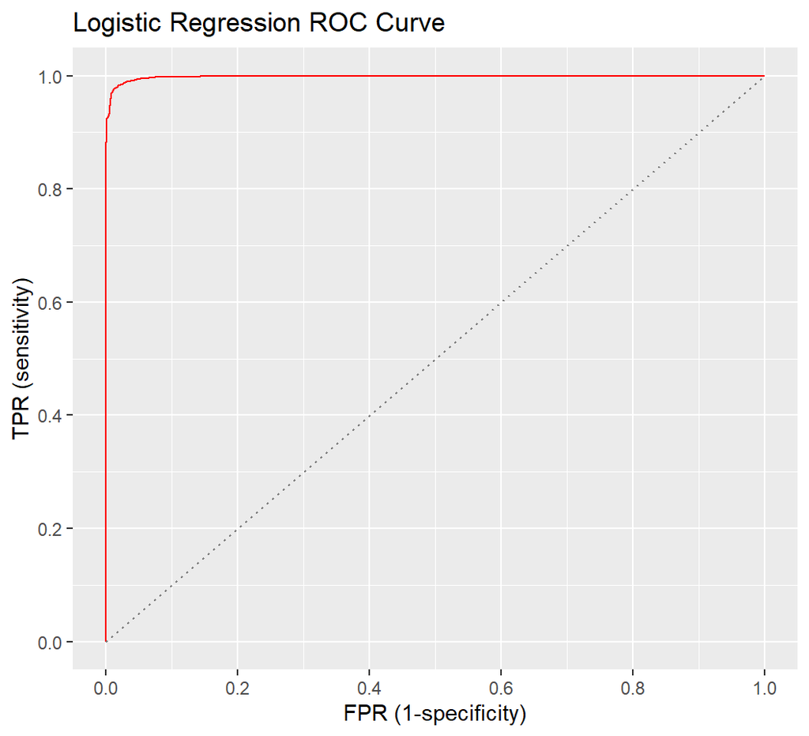

```r
LR_PERF %>%
  ggplot(aes(FPR, TPR)) + geom_path(color="red") +
  labs(x='FPR (1-specificity)', y='TPR (sensitivity)') +
  geom_segment(x=0, xend=1, y=0, yend=1, lty=3, color='grey50') +
  scale_x_continuous(breaks = seq(0, 1, by=.20)) +
  scale_y_continuous(breaks = seq(0, 1, by=.20)) +
  ggtitle("Logistic Regression ROC Curve")
```

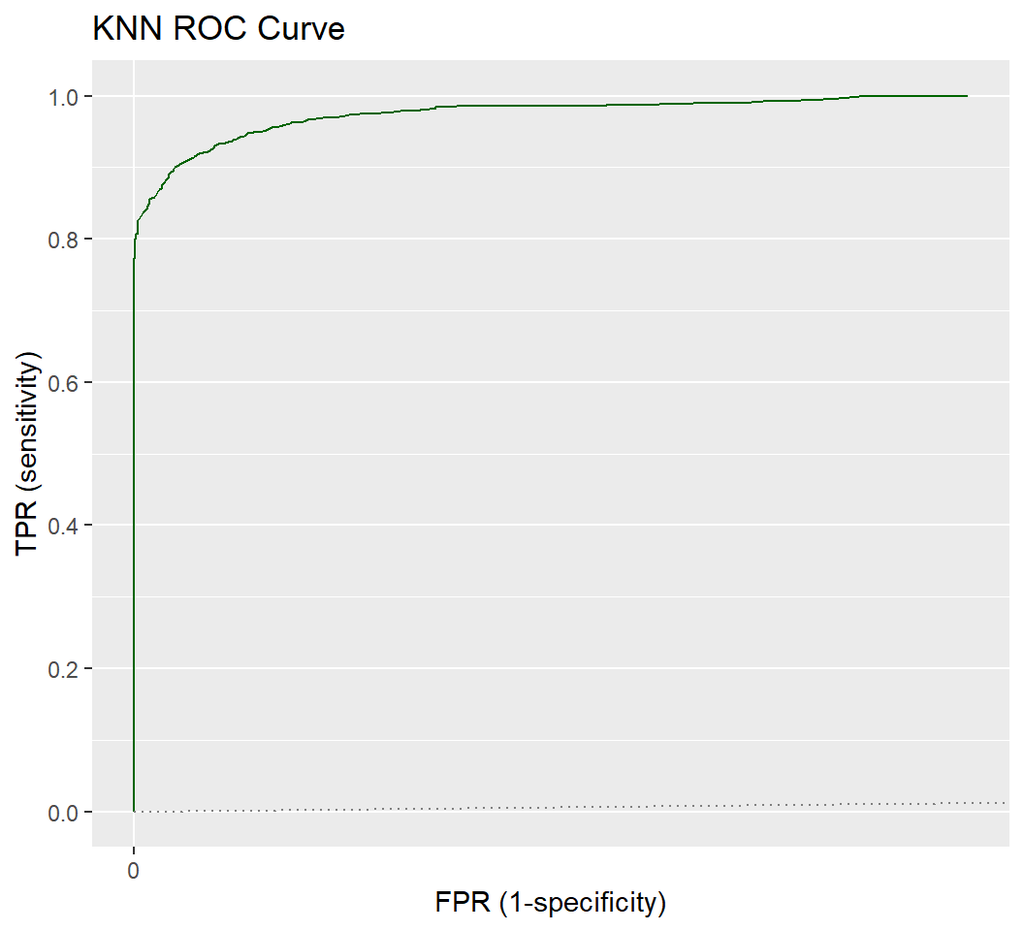

```r
KNN_PERF %>%
  ggplot(aes(FPR, TPR)) + geom_path(color = "dark green") +
  labs(x='FPR (1-specificity)', y='TPR (sensitivity)') +
  geom_segment(x=0, xend=1, y=0, yend=1, lty=3, color='grey50') +
  scale_x_continuous(breaks = seq(0, 1, by=.20)) +
  scale_y_continuous(breaks = seq(0, 1, by=.20)) +
  ggtitle("KNN ROC Curve")
```

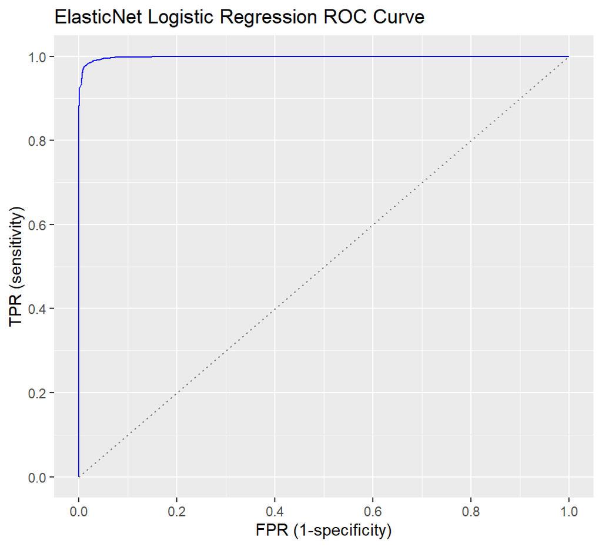

```r
ENET_PERF %>%
  ggplot(aes(FPR, TPR)) + geom_path(color = "blue") +
  labs(x='FPR (1-specificity)', y='TPR (sensitivity)') +
  geom_segment(x=0, xend=1, y=0, yend=1, lty=3, color='grey50') +
  scale_x_continuous(breaks = seq(0, 1, by=.20)) +
  scale_y_continuous(breaks = seq(0, 1, by=.20)) +
  ggtitle("ElasticNet Logistic Regression ROC Curve")
```

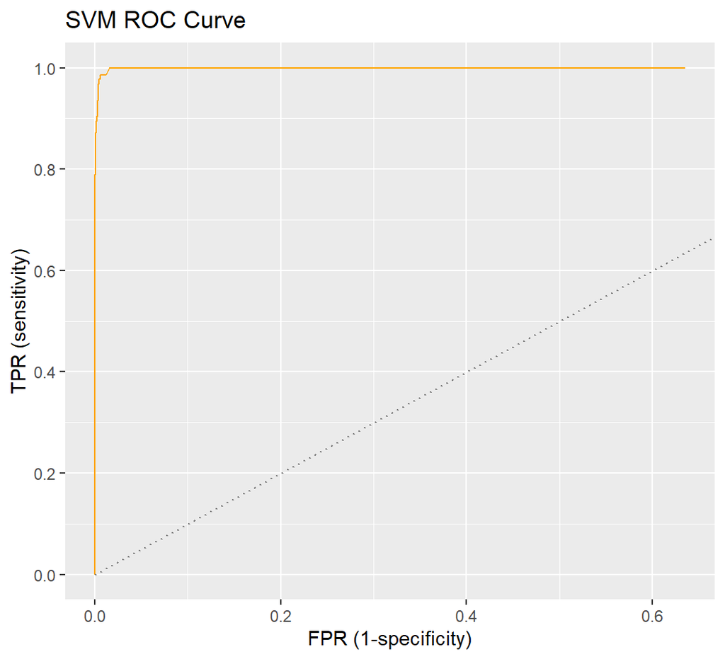

```r
SVM_PERF %>%
  ggplot(aes(FPR, TPR)) + geom_path(color = "orange") +
  labs(x='FPR (1-specificity)', y='TPR (sensitivity)') +
  geom_segment(x=0, xend=1, y=0, yend=1, lty=3, color='grey50') +
  scale_x_continuous(breaks = seq(0, 1, by=.20)) +
  scale_y_continuous(breaks = seq(0, 1, by=.20)) +
  ggtitle("SVM ROC Curve")
```

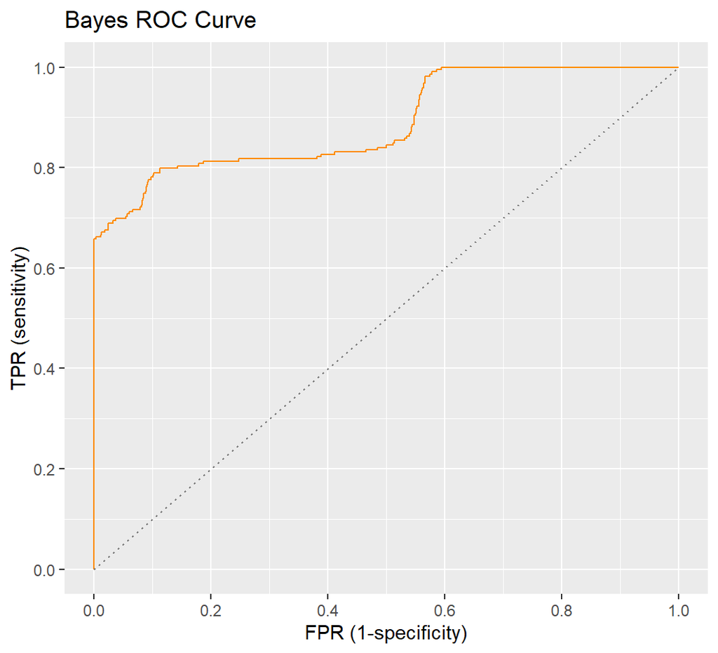

```r
BAYES_PERF %>%
  ggplot(aes(FPR, TPR)) + geom_path(color = "dark orange") +
  labs(x='FPR (1-specificity)', y='TPR (sensitivity)') +
  geom_segment(x=0, xend=1, y=0, yend=1, lty=3, color='grey50') +
  scale_x_continuous(breaks = seq(0, 1, by=.20)) +
  scale_y_continuous(breaks = seq(0, 1, by=.20)) +
  ggtitle("Bayes ROC Curve")
```

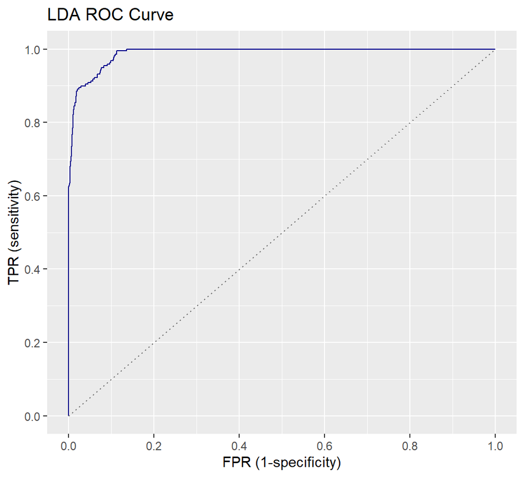

```r
LDA_PERF %>%
  ggplot(aes(FPR, TPR)) + geom_path(color = "dark blue") +
  labs(x='FPR (1-specificity)', y='TPR (sensitivity)') +
  geom_segment(x=0, xend=1, y=0, yend=1, lty=3, color='grey50') +
  scale_x_continuous(breaks = seq(0, 1, by=.20)) +
  scale_y_continuous(breaks = seq(0, 1, by=.20)) +
  ggtitle("LDA ROC Curve")
```

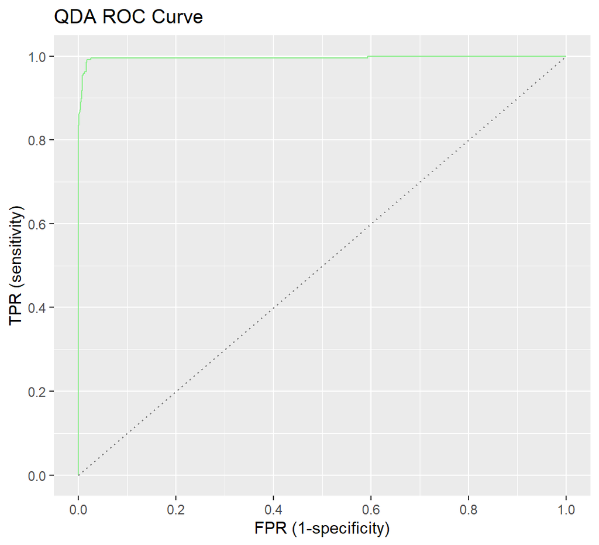

```r
QDA_PERF %>%
  ggplot(aes(FPR, TPR)) + geom_path(color = "light green") +
  labs(x='FPR (1-specificity)', y='TPR (sensitivity)') +
  geom_segment(x=0, xend=1, y=0, yend=1, lty=3, color='grey50') +
  scale_x_continuous(breaks = seq(0, 1, by=.20)) +
  scale_y_continuous(breaks = seq(0, 1, by=.20)) +
  ggtitle("QDA ROC Curve")
```

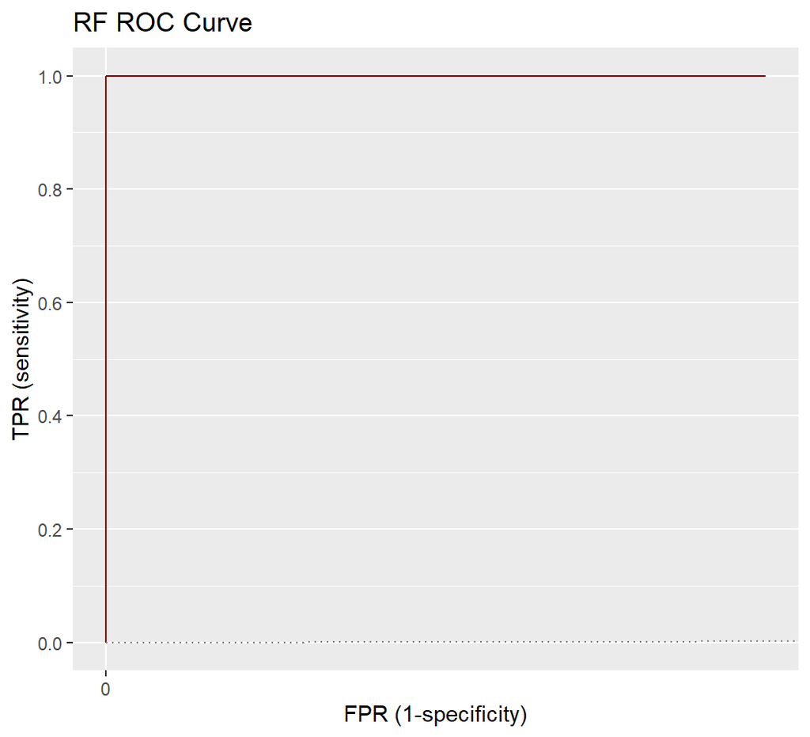

```r
RF_PERF %>%
  ggplot(aes(FPR, TPR)) + geom_path(color = "dark red") +
  labs(x='FPR (1-specificity)', y='TPR (sensitivity)') +
  geom_segment(x=0, xend=1, y=0, yend=1, lty=3, color='grey50') +
  scale_x_continuous(breaks = seq(0, 1, by=.20)) +
  scale_y_continuous(breaks = seq(0, 1, by=.20)) +
  ggtitle("RF ROC Curve")
```

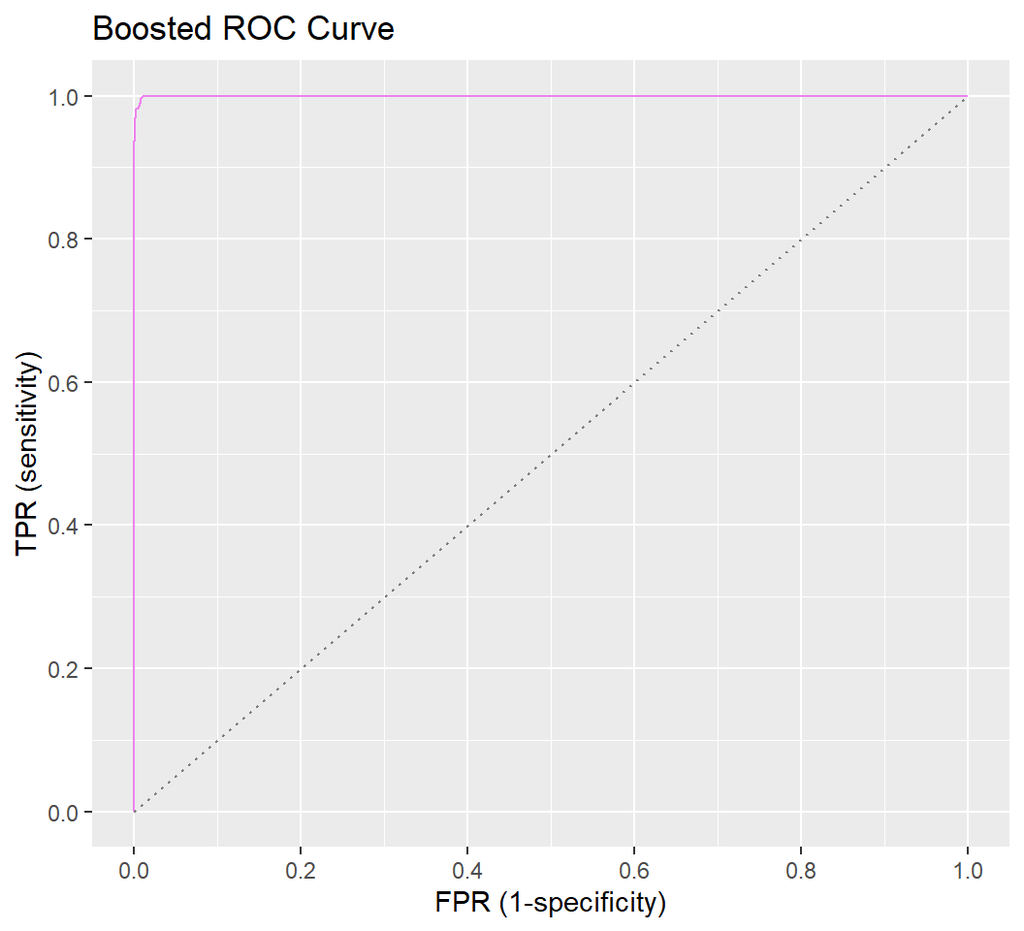

```r
BOOST_PERF %>%
  ggplot(aes(FPR, TPR)) + geom_path(color = "violet") +
  labs(x='FPR (1-specificity)', y='TPR (sensitivity)') +
  geom_segment(x=0, xend=1, y=0, yend=1, lty=3, color='grey50') +
  scale_x_continuous(breaks = seq(0, 1, by=.20)) +
  scale_y_continuous(breaks = seq(0, 1, by=.20)) +
  ggtitle("Boosted ROC Curve")
```

# Hold-Out Performance

## Hold-Out Data Setup

I unzipped, read the files, and combined them into one HoldOut tibble.orthovnir067_ROI_Blue_Tarps_data.txt was not read because it was a repetition of orthovnir067_ROI_Blue_Tarps.txt but without the header lines and other data. I also checked for NA values. It is worth noting that Blue_Tarp accounts for only 0.7% of the HoldOut data, which is significantly less than the 3% found in the training data.

```r
proj.dir = "C:/Users/anz8av/OneDrive - University of Virginia/Documents/Personal Files/UVA/Semesters/Spring 2021-2022/SYS 6018/Project"

unzip(file.path(proj.dir,"HaitiHoldOut.zip"),list = TRUE)
```

```
#>                                    Name   Length                Date
#> 1   orthovnir057_ROI_NON_Blue_Tarps.txt 83238900 2019-11-05 12:15:00
#> 2       orthovnir067_ROI_Blue_Tarps.txt   364839 2019-11-05 11:47:00
#> 3  orthovnir067_ROI_Blue_Tarps_data.txt    60040 2019-11-05 20:59:00
#> 4   orthovnir067_ROI_NOT_Blue_Tarps.txt 25637994 2019-11-05 11:48:00
#> 5       orthovnir069_ROI_Blue_Tarps.txt   560163 2019-11-05 11:55:00
#> 6   orthovnir069_ROI_NOT_Blue_Tarps.txt 24823110 2019-11-05 11:57:00
#> 7  orthovnir071_makeshift_villiage1.jpg    89774 2019-11-05 12:02:00
#> 8  orthovnir071_makeshift_villiage2.jpg    66859 2019-11-05 12:04:00
#> 9  orthovnir078_makeshift_villiage1.jpg   113974 2019-11-05 12:10:00
#> 10      orthovnir078_ROI_Blue_Tarps.txt   263158 2019-11-05 12:12:00
#> 11  orthovnir078_ROI_NON_Blue_Tarps.txt 34414902 2019-11-05 12:14:00
```

```r
unzip(file.path(proj.dir,"HaitiHoldOut.zip"),exdir = proj.dir)

ortho57_noblue = read_table(file.path(proj.dir,"orthovnir057_ROI_NON_Blue_Tarps.txt"),skip = 8,col_names = FALSE) %>% select (Red = X8, Green = X9, Blue = X10) %>% mutate (Blue_Tarp = 0,file = "057")

ortho67_blue = read_table(file.path(proj.dir,"orthovnir067_ROI_Blue_Tarps.txt"),skip = 8,col_names = FALSE) %>% select (Red = X8, Green = X9, Blue = X10) %>% mutate (Blue_Tarp = 1,file = "067")

ortho67_noblue = read_table(file.path(proj.dir,"orthovnir067_ROI_NOT_Blue_Tarps.txt"),skip = 8,col_names = FALSE) %>% select (Red = X8, Green = X9, Blue = X10) %>% mutate (Blue_Tarp = 0,file = "067")

ortho69_noblue = read_table(file.path(proj.dir,"orthovnir069_ROI_NOT_Blue_Tarps.txt"),skip = 8,col_names = FALSE) %>% select (Red = X8, Green = X9, Blue = X10) %>% mutate (Blue_Tarp = 0,file = "069")

ortho69_blue = read_table(file.path(proj.dir,"orthovnir069_ROI_Blue_Tarps.txt"),skip = 8,col_names = FALSE) %>% select (Red = X8, Green = X9, Blue = X10) %>% mutate (Blue_Tarp = 1,file = "069")

ortho78_noblue = read_table(file.path(proj.dir,"orthovnir078_ROI_NON_Blue_Tarps.txt"),skip = 8,col_names = FALSE) %>% select (Red = X8, Green = X9, Blue = X10) %>% mutate (Blue_Tarp = 0,file = "078")

ortho78_blue = read_table(file.path(proj.dir,"orthovnir078_ROI_Blue_Tarps.txt"),skip = 8,col_names = FALSE) %>% select (Red = X8, Green = X9, Blue = X10) %>% mutate (Blue_Tarp = 1,file = "078")

HoldOut = tibble()

HoldOut = bind_rows(ortho57_noblue,ortho67_blue,ortho67_noblue,ortho69_noblue,ortho69_blue,ortho78_noblue, ortho78_blue)

HoldOut = na.omit(HoldOut)
HoldOut %>%
   group_by(Blue_Tarp) %>%
   summarise(n = n()) %>%
   ungroup() %>%
   mutate(p = (n/nrow(HoldOut)))
```

```
#> # A tibble: 2 x 3
#>   Blue_Tarp       n       p
#>       <dbl>   <int>   <dbl>
#> 1         0 1989697 0.993
#> 2         1   14480 0.00722
```

## Hold-Out Predictions

Now we predict using the HoldOut data for all the 9 models.

```r
set.seed(2021)
colors = c("Red","Green","Blue")
truth_HOLDOUT = HoldOut$Blue_Tarp
#Logistic Regression
  prob.lr = predict(fit.lr, newdata = HoldOut[,colors], type="response") # probabilities
  gamma.lr = predict(fit.lr, newdata = HoldOut[,colors], type="link")     # logit (linear part)
  LR_HOLDOUT = tibble(truth = truth_HOLDOUT , p.hat = prob.lr, gamma = gamma.lr)

  LR_PERF_HOLDOUT = LR_HOLDOUT%>%
  group_by(gamma,p.hat) %>%
  summarize(n=n(), n.1=sum(truth), n.0=n-sum(truth)) %>% ungroup() %>%
  #- calculate metrics
  arrange(gamma) %>%
  mutate(FN = cumsum(n.1),    # false negatives
         TN = cumsum(n.0),    # true negatives
         TP = sum(n.1) - FN,  # true positives
         FP = sum(n.0) - TN,  # false positives
         N = cumsum(n),       # number of cases predicted to be 1
         TPR = TP/sum(n.1), FPR = FP/sum(n.0)) %>%
  #- only keep relevant metrics
  select(-n, -n.1, -n.0,gamma,p.hat)

#KNN

  prob.knn = predict(knn, newdata = HoldOut[,columns], type="prob") #   probabilities
  prob.knn = prob.knn[,2] #Probabilities of class 1, which is detecting Blue Tarp
  gamma.knn = log((prob.knn)/(1-prob.knn))
  KNN_HOLDOUT = tibble(truth = truth_HOLDOUT , p.hat = prob.knn, gamma = gamma.knn)

  KNN_PERF_HOLDOUT = KNN_HOLDOUT%>%
  group_by(gamma,p.hat) %>%
  summarize(n=n(), n.1=sum(truth), n.0=n-sum(truth)) %>% ungroup() %>%
  #- calculate metrics
  arrange(gamma) %>%
  mutate(FN = cumsum(n.1),    # false negatives
         TN = cumsum(n.0),    # true negatives
         TP = sum(n.1) - FN,  # true positives
         FP = sum(n.0) - TN,  # false positives
         N = cumsum(n),       # number of cases predicted to be 1
         TPR = TP/sum(n.1), FPR = FP/sum(n.0)) %>%
  #- only keep relevant metrics
  select(-n, -n.1, -n.0,gamma,p.hat)



#Elastic Net

  gamma.enet = predict(fit.enet, s="lambda.min", newx=as.matrix(HoldOut[,colors]), type="link")[,1]
  prob.enet = predict(fit.enet, s="lambda.min", newx=as.matrix(HoldOut[,colors]), type="response")[,1]

  ENET_HOLDOUT = tibble(truth = truth_HOLDOUT , p.hat = prob.enet ,gamma = gamma.enet )
  #Metrics
  ENET_PERF_HOLDOUT = ENET_HOLDOUT %>%
  group_by(gamma,p.hat) %>%
  summarize(n=n(), n.1=sum(truth), n.0=n-sum(truth)) %>% ungroup() %>%
  #- calculate metrics
  arrange(gamma) %>%
  mutate(FN = cumsum(n.1),    # false negatives
         TN = cumsum(n.0),    # true negatives
         TP = sum(n.1) - FN,  # true positives
         FP = sum(n.0) - TN,  # false positives
         N = cumsum(n),       # number of cases predicted to be 1
         TPR = TP/sum(n.1), FPR = FP/sum(n.0)) %>%
  #- only keep relevant metrics
  select(-n, -n.1, -n.0,gamma,p.hat)

#SVM
  preds = predict(fit.svm, HoldOut[,colors], probability = TRUE)
  prob.svm = attributes(preds)$probabilities[,2]
  gamma.svm = log(prob.svm)/(1-prob.svm)

  SVM_HOLDOUT = tibble(truth = truth_HOLDOUT , p.hat = prob.svm ,gamma = gamma.svm )
  #Metrics
  SVM_PERF_HOLDOUT = SVM_HOLDOUT %>%
  group_by(gamma,p.hat) %>%
  summarize(n=n(), n.1=sum(truth), n.0=n-sum(truth)) %>% ungroup() %>%
  #- calculate metrics
  arrange(gamma) %>%
  mutate(FN = cumsum(n.1),    # false negatives
         TN = cumsum(n.0),    # true negatives
         TP = sum(n.1) - FN,  # true positives
         FP = sum(n.0) - TN,  # false positives
         N = cumsum(n),       # number of cases predicted to be 1
         TPR = TP/sum(n.1), FPR = FP/sum(n.0)) %>%
  #- only keep relevant metrics
  select(-n, -n.1, -n.0,gamma,p.hat)

#Naive Bayes
  pred_temp = predict(bayes, HoldOut[,colors], type="raw")
  prob.bayes = pred_temp[,2]
  gamma.bayes = log(prob.bayes)/(prob.bayes)

  BAYES_HOLDOUT = tibble(p.hat = prob.bayes,truth = truth_HOLDOUT, gamma = gamma.bayes)

  #Metrics
  BAYES_PERF_HOLDOUT = BAYES_HOLDOUT %>%
  group_by(gamma,p.hat) %>%
  summarize(n=n(), n.1=sum(truth), n.0=n-sum(truth)) %>% ungroup() %>%
  #- calculate metrics
  arrange(gamma) %>%
  mutate(FN = cumsum(n.1),    # false negatives
         TN = cumsum(n.0),    # true negatives
         TP = sum(n.1) - FN,  # true positives
         FP = sum(n.0) - TN,  # false positives
         N = cumsum(n),       # number of cases predicted to be 1
         TPR = TP/sum(n.1), FPR = FP/sum(n.0)) %>%
  #- only keep relevant metrics
  select(-n, -n.1, -n.0,gamma,p.hat)

#LDA
  pred_temp = predict(ld, HoldOut[,colors], probability = TRUE)
  prob.lda = pred_temp$posterior[,2]
  gamma.lda = log(prob.lda)/(1-prob.lda)

  LDA_HOLDOUT = tibble(p.hat = prob.lda,truth = truth_HOLDOUT,gamma = gamma.lda)

  #Metrics
  LDA_PERF_HOLDOUT = LDA_HOLDOUT %>%
  group_by(gamma,p.hat) %>%
  summarize(n=n(), n.1=sum(truth), n.0=n-sum(truth)) %>% ungroup() %>%
  #- calculate metrics
  arrange(gamma) %>%
  mutate(FN = cumsum(n.1),    # false negatives
         TN = cumsum(n.0),    # true negatives
         TP = sum(n.1) - FN,  # true positives
         FP = sum(n.0) - TN,  # false positives
         N = cumsum(n),       # number of cases predicted to be 1
         TPR = TP/sum(n.1), FPR = FP/sum(n.0)) %>%
  #- only keep relevant metrics
  select(-n, -n.1, -n.0,gamma,p.hat)

#QDA
  pred_temp = predict(qd, HoldOut[,colors], probability = TRUE)
  prob.qda = pred_temp$posterior[,2]
  gamma.qda = log(prob.qda)/(1-prob.qda)

  QDA_HOLDOUT = tibble(p.hat = prob.qda,truth = truth_HOLDOUT,gamma = gamma.qda)

  #Metrics
  QDA_PERF_HOLDOUT = QDA_HOLDOUT %>%
  group_by(gamma,p.hat) %>%
  summarize(n=n(), n.1=sum(truth), n.0=n-sum(truth)) %>% ungroup() %>%
  #- calculate metrics
  arrange(gamma) %>%
  mutate(FN = cumsum(n.1),    # false negatives
         TN = cumsum(n.0),    # true negatives
         TP = sum(n.1) - FN,  # true positives
         FP = sum(n.0) - TN,  # false positives
         N = cumsum(n),       # number of cases predicted to be 1
         TPR = TP/sum(n.1), FPR = FP/sum(n.0)) %>%
  #- only keep relevant metrics
  select(-n, -n.1, -n.0,gamma,p.hat)

#Random Forest
  pred_temp = predict(rf_opt, HoldOut, type="prob")
  prob.rf = pred_temp[,2]
  gamma.rf = log(prob.rf)/(1-prob.rf)

  RF_HOLDOUT = tibble(p.hat = prob.rf,truth = truth_HOLDOUT, gamma = gamma.rf)

  #Metrics
  RF_PERF_HOLDOUT = RF_HOLDOUT %>%
  group_by(gamma,p.hat) %>%
  summarize(n=n(), n.1=sum(truth), n.0=n-sum(truth)) %>% ungroup() %>%
  #- calculate metrics
  arrange(gamma) %>%
  mutate(FN = cumsum(n.1),    # false negatives
         TN = cumsum(n.0),    # true negatives
         TP = sum(n.1) - FN,  # true positives
         FP = sum(n.0) - TN,  # false positives
         N = cumsum(n),       # number of cases predicted to be 1
         TPR = TP/sum(n.1), FPR = FP/sum(n.0)) %>%
  #- only keep relevant metrics
  select(-n, -n.1, -n.0,gamma,p.hat)

#Boosted Trees
  #I had to use a different xgb function since xgb.cv doesn't support predict().

    xgb_opt = xgboost::xgboost(
    as.matrix(X.train),
    label = Y.train,
    max.depth = 3,
    eta = 0.07,
    nrounds = 700,
    objective = "binary:logistic",
    verbose = FALSE)

  HoldOut_nolabel = tibble(HoldOut[,colors])
  pred_temp = predict(xgb_opt, xgboost::xgb.DMatrix(data = as.matrix(HoldOut_nolabel), label = HoldOut$Blue_Tarp))
  prob.xgb = pred_temp
  gamma.xgb = log(prob.xgb)/(1-prob.xgb)

  BOOST_HOLDOUT = tibble(p.hat = prob.xgb,truth = truth_HOLDOUT, gamma = gamma.xgb)

  #Metrics
  BOOST_PERF_HOLDOUT = BOOST_HOLDOUT %>%
  group_by(gamma,p.hat) %>%
  summarize(n=n(), n.1=sum(truth), n.0=n-sum(truth)) %>% ungroup() %>%
  #- calculate metrics
  arrange(gamma) %>%
  mutate(FN = cumsum(n.1),    # false negatives
         TN = cumsum(n.0),    # true negatives
         TP = sum(n.1) - FN,  # true positives
         FP = sum(n.0) - TN,  # false positives
         N = cumsum(n),       # number of cases predicted to be 1
         TPR = TP/sum(n.1), FPR = FP/sum(n.0)) %>%
  #- only keep relevant metrics
  select(-n, -n.1, -n.0,gamma,p.hat)
```

## Hold-Out Performance Table

I am using the same p-threshold as that used in the CV table ($p ~= 0.1428$).

```r
LR_ROW = 326597
KNN_ROW = 119
ENET_ROW = 326709
SVM_ROW = 195271
BAYES_ROW = 335097
LDA_ROW = 336403
QDA_ROW = 336404
RF_ROW = 80
BOOST_ROW = 43913

# I found the rows manually and binded them to a single tibble. I found the closest p value to the threshold.
Model = c("Logistic Regression","KNN","ElasticNet","SVM","Naive Bayes","LDA","QDA","Random Forest","Boosted Trees")
Tuning = c("","k = 39","lambda_min = 5.5e-6 & alpha  = 1","cost = 0.1 & gamma  = 0.1","","","","mtry = 2, ntree = 1000","eta = 0.07 & nrounds = 700")

PERF_THRES2 = tibble()
PERF_THRES2 = bind_rows(PERF_THRES2,LR_PERF_HOLDOUT[LR_ROW,c("TPR","FPR")])
PERF_THRES2 = bind_rows(PERF_THRES2,KNN_PERF_HOLDOUT[KNN_ROW,c("TPR","FPR")])
PERF_THRES2 = bind_rows(PERF_THRES2,ENET_PERF_HOLDOUT[ENET_ROW,c("TPR","FPR")])
PERF_THRES2 = bind_rows(PERF_THRES2,SVM_PERF_HOLDOUT[SVM_ROW,c("TPR","FPR")])
PERF_THRES2 = bind_rows(PERF_THRES2,BAYES_PERF_HOLDOUT[BAYES_ROW,c("TPR","FPR")])
PERF_THRES2 = bind_rows(PERF_THRES2,LDA_PERF_HOLDOUT[LDA_ROW,c("TPR","FPR")])
PERF_THRES2 = bind_rows(PERF_THRES2,QDA_PERF_HOLDOUT[QDA_ROW,c("TPR","FPR")])
PERF_THRES2 = bind_rows(PERF_THRES2,RF_PERF_HOLDOUT[RF_ROW,c("TPR","FPR")])
PERF_THRES2 = bind_rows(PERF_THRES2,BOOST_PERF_HOLDOUT[BOOST_ROW,c("TPR","FPR")])

#Precision calculations
LR_Prec2 = LR_PERF_HOLDOUT[LR_ROW,"TP"]/(LR_PERF_HOLDOUT[LR_ROW,"TP"]+LR_PERF_HOLDOUT[LR_ROW,"FP"])
KNN_Prec2 = KNN_PERF_HOLDOUT[KNN_ROW,"TP"]/(KNN_PERF_HOLDOUT[KNN_ROW,"TP"]+KNN_PERF_HOLDOUT[KNN_ROW,"FP"])
ENET_Prec2 = ENET_PERF_HOLDOUT[ENET_ROW,"TP"]/(ENET_PERF_HOLDOUT[ENET_ROW,"TP"]+ENET_PERF_HOLDOUT[ENET_ROW,"FP"])
SVM_Prec2 = SVM_PERF_HOLDOUT[SVM_ROW,"TP"]/(SVM_PERF_HOLDOUT[SVM_ROW,"TP"]+SVM_PERF_HOLDOUT[SVM_ROW,"FP"])
BAYES_Prec2 = BAYES_PERF_HOLDOUT[BAYES_ROW,"TP"]/(BAYES_PERF_HOLDOUT[BAYES_ROW,"TP"]+BAYES_PERF_HOLDOUT[BAYES_ROW,"FP"])
LDA_Prec2 = LDA_PERF_HOLDOUT[LDA_ROW,"TP"]/(LDA_PERF_HOLDOUT[LDA_ROW,"TP"]+LDA_PERF_HOLDOUT[LDA_ROW,"FP"])
QDA_Prec2 = QDA_PERF_HOLDOUT[QDA_ROW,"TP"]/(QDA_PERF_HOLDOUT[QDA_ROW,"TP"]+QDA_PERF_HOLDOUT[QDA_ROW,"FP"])
RF_Prec2 = RF_PERF_HOLDOUT[RF_ROW,"TP"]/(RF_PERF_HOLDOUT[RF_ROW,"TP"]+RF_PERF_HOLDOUT[RF_ROW,"FP"])
BOOST_Prec2 = BOOST_PERF_HOLDOUT[BOOST_ROW,"TP"]/(BOOST_PERF_HOLDOUT[BOOST_ROW,"TP"]+BOOST_PERF_HOLDOUT[BOOST_ROW,"FP"])

Precision2 = c(LR_Prec2,KNN_Prec2,ENET_Prec2,SVM_Prec2,BAYES_Prec2,LDA_Prec2,QDA_Prec2,RF_Prec2,BOOST_Prec2)

#Accuracy calculations
LR_Acc2 = (LR_PERF_HOLDOUT[LR_ROW,"TP"]+LR_PERF_HOLDOUT[LR_ROW,"TN"])/(LR_PERF_HOLDOUT[LR_ROW,"TP"]+LR_PERF_HOLDOUT[LR_ROW,"TN"]+LR_PERF_HOLDOUT[LR_ROW,"FP"]+LR_PERF_HOLDOUT[LR_ROW,"FN"])
KNN_Acc2 = (KNN_PERF_HOLDOUT[KNN_ROW,"TP"]+KNN_PERF_HOLDOUT[KNN_ROW,"TN"])/(KNN_PERF_HOLDOUT[KNN_ROW,"TP"]+KNN_PERF_HOLDOUT[KNN_ROW,"TN"]+KNN_PERF_HOLDOUT[KNN_ROW,"FP"]+KNN_PERF_HOLDOUT[KNN_ROW,"FN"])
ENET_Acc2 = (ENET_PERF_HOLDOUT[ENET_ROW,"TP"]+ENET_PERF_HOLDOUT[ENET_ROW,"TN"])/(ENET_PERF_HOLDOUT[ENET_ROW,"TP"]+ENET_PERF_HOLDOUT[ENET_ROW,"TN"]+ENET_PERF_HOLDOUT[ENET_ROW,"FP"]+ENET_PERF_HOLDOUT[ENET_ROW,"FN"])
SVM_Acc2 = (SVM_PERF_HOLDOUT[SVM_ROW,"TP"]+SVM_PERF_HOLDOUT[SVM_ROW,"TN"])/(SVM_PERF_HOLDOUT[SVM_ROW,"TP"]+SVM_PERF_HOLDOUT[SVM_ROW,"TN"]+SVM_PERF_HOLDOUT[SVM_ROW,"FP"]+SVM_PERF_HOLDOUT[SVM_ROW,"FN"])
BAYES_Acc2 = (BAYES_PERF_HOLDOUT[BAYES_ROW,"TP"]+BAYES_PERF_HOLDOUT[BAYES_ROW,"TN"])/(BAYES_PERF_HOLDOUT[BAYES_ROW,"TP"]+BAYES_PERF_HOLDOUT[BAYES_ROW,"TN"]+BAYES_PERF_HOLDOUT[BAYES_ROW,"FP"]+BAYES_PERF_HOLDOUT[BAYES_ROW,"FN"])
LDA_Acc2 = (LDA_PERF_HOLDOUT[LDA_ROW,"TP"]+LDA_PERF_HOLDOUT[LDA_ROW,"TN"])/(LDA_PERF_HOLDOUT[LDA_ROW,"TP"]+LDA_PERF_HOLDOUT[LDA_ROW,"TN"]+LDA_PERF_HOLDOUT[LDA_ROW,"FP"]+LDA_PERF_HOLDOUT[LDA_ROW,"FN"])
QDA_Acc2 = (QDA_PERF_HOLDOUT[QDA_ROW,"TP"]+QDA_PERF_HOLDOUT[QDA_ROW,"TN"])/(QDA_PERF_HOLDOUT[QDA_ROW,"TP"]+QDA_PERF_HOLDOUT[QDA_ROW,"TN"]+QDA_PERF_HOLDOUT[QDA_ROW,"FP"]+QDA_PERF_HOLDOUT[QDA_ROW,"FN"])
RF_Acc2 = (RF_PERF_HOLDOUT[RF_ROW,"TP"]+RF_PERF_HOLDOUT[RF_ROW,"TN"])/(RF_PERF_HOLDOUT[RF_ROW,"TP"]+RF_PERF_HOLDOUT[RF_ROW,"TN"]+RF_PERF_HOLDOUT[RF_ROW,"FP"]+RF_PERF_HOLDOUT[RF_ROW,"FN"])
BOOST_Acc2 = (BOOST_PERF_HOLDOUT[BOOST_ROW,"TP"]+BOOST_PERF_HOLDOUT[BOOST_ROW,"TN"])/(BOOST_PERF_HOLDOUT[BOOST_ROW,"TP"]+BOOST_PERF_HOLDOUT[BOOST_ROW,"TN"]+BOOST_PERF_HOLDOUT[BOOST_ROW,"FP"]+BOOST_PERF_HOLDOUT[BOOST_ROW,"FN"])

Accuracy2 = c(LR_Acc2,KNN_Acc2,ENET_Acc2,SVM_Acc2,BAYES_Acc2,LDA_Acc2,QDA_Acc2,RF_Acc2,BOOST_Acc2)


#AUROC calculations
LR_AUROC2 = yardstick::roc_auc_vec(factor(LR_HOLDOUT$truth, 1:0), LR_HOLDOUT$p.hat)
KNN_AUROC2 = yardstick::roc_auc_vec(factor(KNN_HOLDOUT$truth, 1:0), KNN_HOLDOUT$p.hat)
ENET_AUROC2 = yardstick::roc_auc_vec(factor(ENET_HOLDOUT$truth, 1:0), ENET_HOLDOUT$p.hat)
SVM_AUROC2 = yardstick::roc_auc_vec(factor(SVM_HOLDOUT$truth, 1:0), SVM_HOLDOUT$gamma)
BAYES_AUROC2 = yardstick::roc_auc_vec(factor(BAYES_HOLDOUT$truth, 1:0), BAYES_HOLDOUT$p.hat)
LDA_AUROC2 = yardstick::roc_auc_vec(factor(LDA_HOLDOUT$truth, 1:0), LDA_HOLDOUT$p.hat)
QDA_AUROC2 = yardstick::roc_auc_vec(factor(QDA_HOLDOUT$truth, 1:0), QDA_HOLDOUT$p.hat)
RF_AUROC2 = yardstick::roc_auc_vec(factor(RF_HOLDOUT$truth, 1:0), RF_HOLDOUT$p.hat)
BOOST_AUROC2 = yardstick::roc_auc_vec(factor(BOOST_HOLDOUT$truth, 1:0), BOOST_HOLDOUT$p.hat)

AUROC2 = c(LR_AUROC2,KNN_AUROC2,ENET_AUROC2,SVM_AUROC2,BAYES_AUROC2,LDA_AUROC2,QDA_AUROC2,RF_AUROC2,BOOST_AUROC2)


#Organize tibble
PERF_THRES2 = tibble(Model,Tuning,AUROC = AUROC2,Threshold = "p =~ 0.1428", Accuracy = Accuracy2,TPR = PERF_THRES2$TPR,FPR = PERF_THRES2$FPR, Precision  = Precision2)

knitr::kable(PERF_THRES2,"pipe",align = "lccrr")
```

| Model | Tuning | AUROC | Threshold | Accuracy | TPR | FPR | Precision |
| --- | --- | --- | --- | --- | --- | --- | --- |
| Logistic Regression |  | 0.9994015 | p =~ 0.1428 | 0.9404184 | 0.9991713 | 0.0600091 | 0.1080766 |
| KNN | k = 39 | 0.9563918 | p =~ 0.1428 | 0.9840343 | 0.8997928 | 0.0153526 | 0.2989949 |
| ElasticNet | lambda_min = 5.5e-6 & alpha = 1 | 0.9994401 | p =~ 0.1428 | 0.9425195 | 0.9991713 | 0.0578927 | 0.1115867 |
| SVM | cost = 0.1 & gamma = 0.1 | 0.9992330 | p =~ 0.1428 | 0.9878703 | 0.9921961 | 0.0121611 | 0.3725495 |
| Naive Bayes |  | 0.7827421 | p =~ 0.1428 | 0.9810541 | 0.2664365 | 0.0137453 | 0.1236261 |
| LDA |  | 0.9921013 | p =~ 0.1428 | 0.9773169 | 0.9084945 | 0.0221823 | 0.2296172 |
| QDA |  | 0.9910478 | p =~ 0.1428 | 0.9833338 | 0.7893646 | 0.0152546 | 0.2735628 |
| Random Forest | mtry = 2, ntree = 1000 | 1.0000000 | p =~ 0.1428 | 0.9997685 | 0.9679558 | 0.0000000 | 1 |
| Boosted Trees | eta = 0.07 & nrounds = 700 | 0.9771945 | p =~ 0.1428 | 0.98829 | 0.7982735 | 0.0103272 | 0.360015 |

# Conclusions

## Conclusion #1

Analyzing both the CV and holdout performance tables, the optimized RF model is the best. Looking at AUROC, accuracy, TPR, and FPR, an argument could be made for other models such as SVM or KNN, but what set the RF model apart from the others was its precision. While all other models significantly dipped in precision, the RF model maintained an almost perfect precision.

## Conclusion #4

The performance table above showed that we cannot rely on a single metric to assess our models’ performance. For example, had we relied solely on accuracy, it would’ve appeared that Naive Bayes and RF are quite similar in performance, but looking at the other metrics shows that RF is indeed superior.

## Conclusion #5

It seems that the classifiers (Bayes, LDA, QDA) were unimpressive in this context, and this may indicate that they aren’t well suited for this task. This may have to do with the data distribution.

## Conclusion #6

I found it interesting that almost all the models preserved their accuracy, AUROC, TPR, and FPR numbers, but their precision numbers significantly fell. Low precision means that the classifier returns a lot of false positives (falsely classifying a portion as Blue Tarp). Going back to the costs that we allocated ($C_{FP} = 1$ and $C_{FN} = 6$), low precision may not be a significant issue, so models other than RF may be considered appropriate if forced to pick something else.However, recall that my choice of costs was arbitrary, so a different cost assignment may deem precision more crucial and give an even bigger edge to the RF model.

## Conclusion #7

I believe the fall in precision has to do with the data composition of the HoldOut data. Blue_Tarp was already relatively rare in the training data (~3%), and it was even rarer in the testing data (~0.7%). This definitely has an impact on precision.

## Conclusion #8

Regarding the Naive Bayes classifier (which was clearly the worst performer of the 9), perhaps the data distribution and the nature of the task isn’t suitable. According to the R documentation of the naiveBayes function, the implementation assumes gaussian distribution of the metric predictors and independence of the predictor variables. It might’ve performed better with a more balanced dataset, or in a problem involving multiclasses, historical prediction, or text classification. Perhaps a different implementation of the Bayes classifier (such as multinomial Bayes) would’ve shown much better performance as well.